# RaceReport

## Fantasy League Scores

Scores for drivers/constructors in the current year's fantasy league, along with manager/team points, values, and statistics. Note: driver and constructor values are taken as the cost to enter the current race and are updated the week before the race.

## Lineup Scores

In the final round of the season, it's the outgoing world champion Max Verstappen who takes the top spot with a dominant win, coming home with 46 points. In second place, it's a return to form for Ferrari's Charles Leclerc with 35 points, ahead of Lando Norris in third place with 29 points. Piastri and Hamilton tie for fourth place with 28 points, while Nico Hulkenberg rounds out the top five with 24. Isack Hadjar comes away from the final race with -2 points at the bottom of the grid, behind Franco Colapinto who has another pointless race. Liam Lawson and Yuki Tsunoda tie for third-worst with 1 point, behind Sainz and Gasly with 3. Kimi Antonelli finishes his rookie season with 5 points.

Surprisingly, it's the Prancing Horse that takes the top step this week with a huge 83 points ahead of 2025 champions McLaren with 77. Red Bull round out the podium with 52 points. Alpine come home from Abu Dhabi with another disappointing score of 4 points, behind Racing Bulls with 6. Williams round out the bottom three with 24 points.

McLaren finish their dominant season with 1744 points, ahead of a very tight battle for the podium. Red Bull just hold on with 1227 points, with Mercedes in third place with 1185 points. Ferrari just miss out on the podium with 1145 points. Then we have another tense battle for fifth with Williams taking the honours with 490 points, ahead of Haas and Racing Bulls with 482 and 462 points, respectively. Then we have another battle with the victors Aston Martin in eighth place with 344 points, ahead of Kick Sauber with 307 points. Alpine are in a league of their own at the bottom with 165 points.

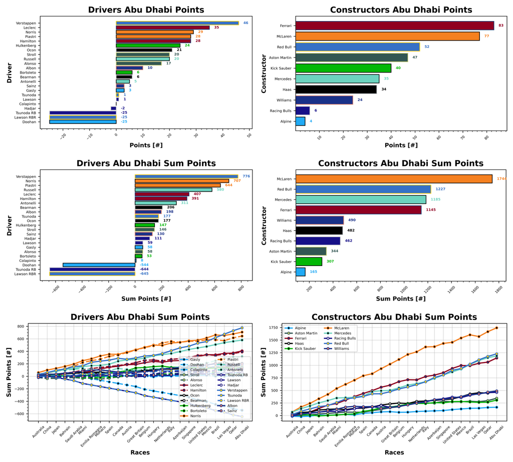

Norris finishes the season with a value of 30.3, with Verstappen close behind at 30.1. Piastri's value has dropped lately, and he finishes the season at 25.1. George Russell's consistency is rewarded with a value of 23.7, with Charles Leclerc in fifth at 23.0. Franco Colapinto finishes his first "full" season with a value of 4.5, behind Fernando Alonso at 4.7. The Kick Saubers next with Hulkenberg at 5.0 and Bortoleto at 5.5. Liam Lawson rounds out the cheap five with a value of 5.9.

McLaren finish their championship season with a season high of 36.1, with Ferrari in second at 31.8, and Red Bull in third with 31.1. Kick Sauber were your cheapest team of the season at 8.7, followed by Alpine at 10.1 and Aston Martin at 10.3.

All values are in Million Dollars.

Driver of the season goes to George Russell, who is the only driver of the 2025 season to score positive points at every race, a 100% record for the Mercedes man is very impressive. Max Verstappen joins him at the top with a 95.8% positive scoring record, followed by Esteban Ocon with 91.7%. Norris and Hamilton make it fourth with 87.5%, followed by Leclerc, Piastri, Bearman, and Albon with 83.3%. Your worst driver of the season is by far Franco Colapinto who only manages 41.7% positive scoring record, behind Bortoleto and Lawson with 62.5%. Alonso and Gasly make it 2/3 positive score (66.7%) behind Tsunoda and Stroll with 70.8%. Sainz, Hulkenberg, and Hadjar round out the bottom five with 3/4 positive scoring record (75%). As he's the only driver to not be mentioned, Kimi Antonelli sits in the middle with a 79.2% record.

Red Bull and Mercedes complete their season with a 100% record, ahead of McLaren with 95.8%. Williams round out the podium with 91.7% positive scoring. Haas and Ferrari tie with 87.5%, ahead of Racing Bulls, Aston martin, and Alpine with 79.17%. Kick Sauber finish the season with a 3/4 rate, a 75% positive scoring record. Very consistent from all the teams there.

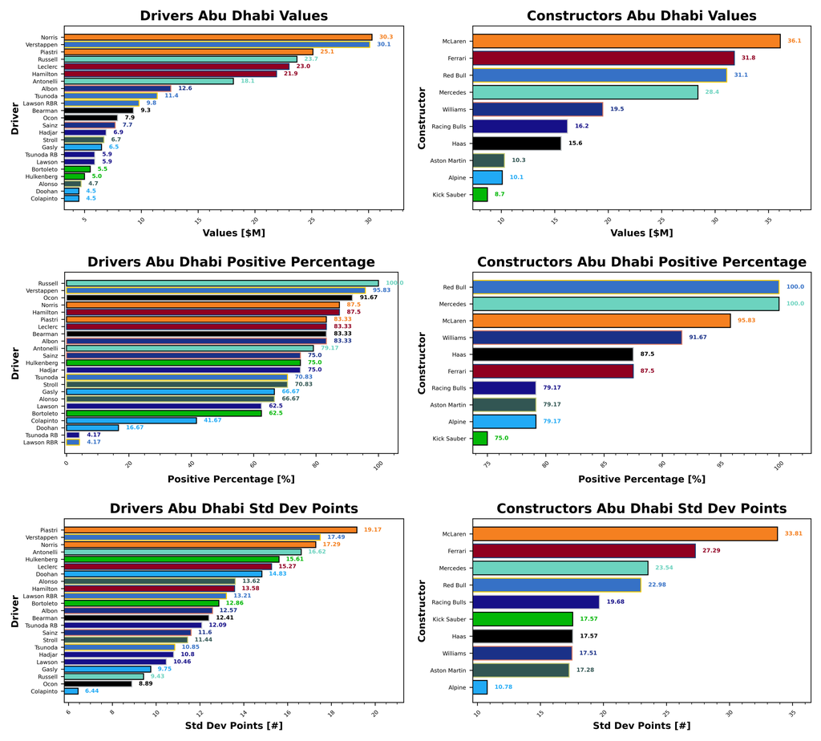

Colapinto remains your most consistent driver of the season with a standard deviation of 6.44 points. He's joined by Ocon, Russell, Gasly, and Lawson with standard deviations of 8.9, 9.4, 9.8, and 10.5. Your least reliable driver of the season is Oscar Piastri with a standard deviation of 19.2, followed by Max Verstappen with 17.5, Lando Norris with 17.3, Antonelli with 16.6, and Nico Hulkenberg with 15.6.

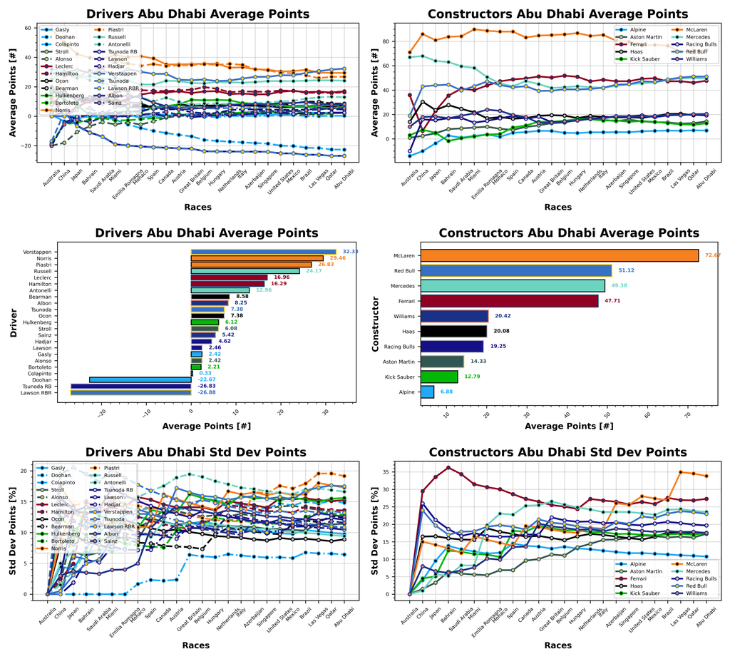

Driver of the week is Nico Huuuuulkenberggggg with a points per value of 4.8 ppm, ahead of Fernando Alonso and Lance Stroll with 3.62 and 2.99 ppm. Crazy how Aston were so quick in Abu Dhabi. Esteban Ocon next with 2.66 ppm, and Max Verstappen rounds out the top five with 1.53 ppm. Isack Hadjar was your worst driver of the weekend with -0.29 ppm, behind Colapinto with 0 ppm. Tsunoda next with 0.09 ppm, behind Liam Lawson with 0.17 ppm. Kimi Antonelli rounds out the bottom five with 0.28 ppm.

Kick Sauber just clinch team of the week this week with a points per value of 4.6 ppm, ahead of Aston martin with 4.56 ppm. Ferrari round out the podium with 2.61 ppm. Racing Bulls were your worst team of the week with 0.37 ppm, behind Alpine with 0.4 ppm. Williams and Mercedes tie for third-worst with 1.23 ppm.

ppm = points per million Dollars.

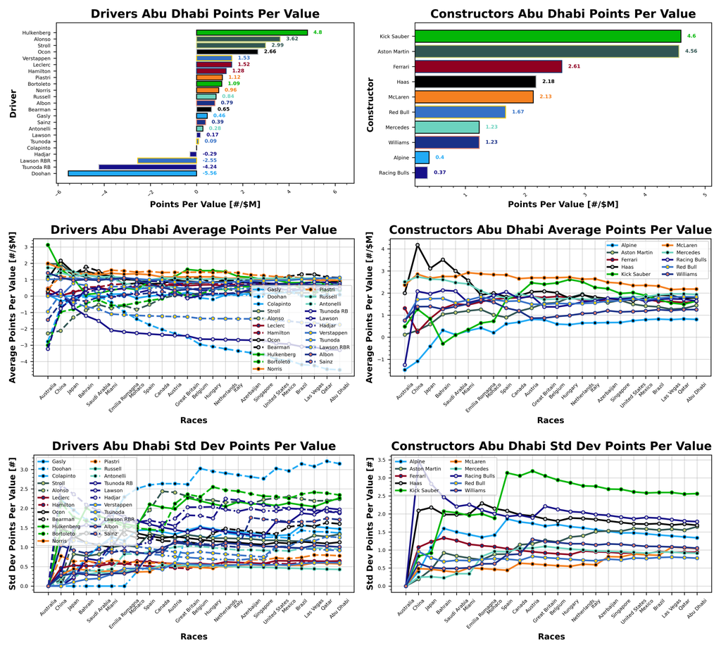

### Manager Scores

Victory at the final race of the season goes to Stefanus and Syahrul with 264 points. It's a 2-3 from Phil this week with BMW Motorrad and BMW FTW with 253 and 249 points. Val and Limoncello44 are in fourth place with 245 points, and Josh rounds out the top five with Expensify APX GP with 238 points.

Stuart and Taylormade To Lose take victory in the Golf League this week with 4 points, followed by Valerie's arm of teams. Perez For World Champion, 20, Stroll to the 18th and What Arrrgh Ya Doohan, 24, round out the podium. Then we have Pete and Seagiant F1 Online with 56 points, followed by James and Bwoah Schweppes Puma Golf with 63.

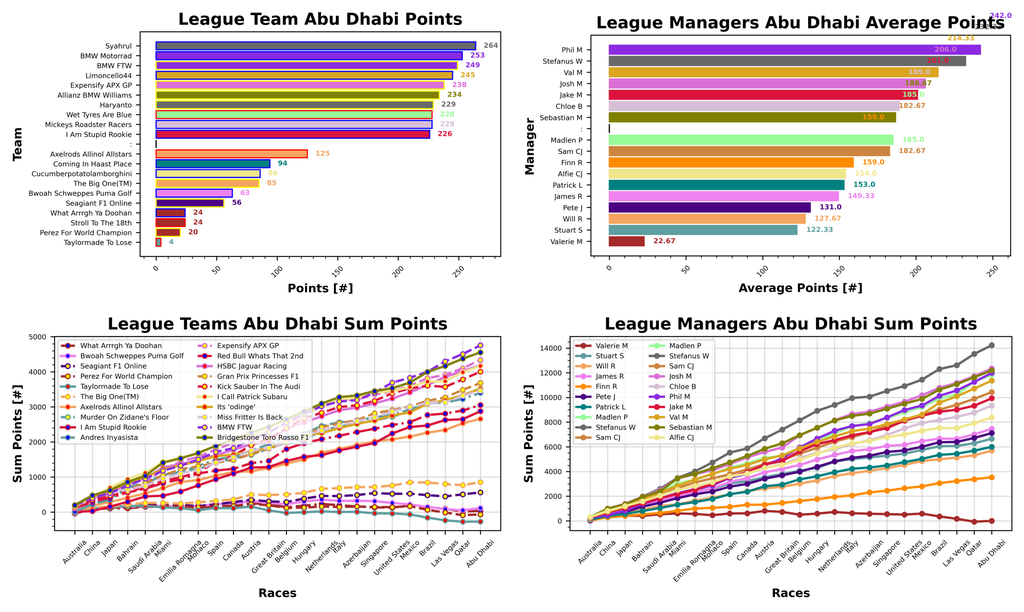

Stefanus and Syahrul take the championship this year, for our first back-to-back winner, with a total of 5091 points. For reference, this is around 400 points fewer than the winning team last year, despite the extra race! Phil comes home in second with BMW FTW with 4758 points, ahead of Patrick and You Hadjar Chance Racing with 4721 points. Stefanus and Haryanto take fourth place with 4648, and rookie manager Sebastian and Bridgestone Toro Rosso F1 rounds out the top five with 4557 points.

Stuart and Taylormade To Lose take the Golf League title this year with a staggering -268 points. Again, this is -40 points more than last year's winning team. Valerie and Perez for World Champion come home in second with -65 points, ahead of Stroll to the 18th with 29 and What Arrrgh Ya Doohan with 38 points. Outgoing champion James and Bwoah Schweppes Puma Golf round out the bottom five with 117 points.

Biggest winner of the week is Phil and BMW Motorrad who jump 3 places in the standings at the final hurdle. Biggest loser of the week is Sam and Total F1 Performance who drop 3 places.

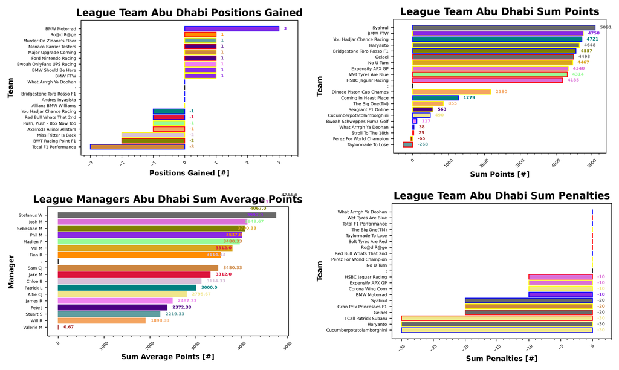

Isack Hadjar completes the season as the most popular driver for your teams, with a total of 31 appearances across the grid. He's followed by Fernando Alonso with 21 and Carlos Sainz with 19. Nico Hulkenberg comes home in fourth with 18, followed by Oscar Piastri with 17 selections. Your least selected drivers this week were Lewis Hamilton and Yuki Tsunoda with 2 selections. They're followed by Lance Stroll with 3, and Charles Leclerc with 4. Russell and Antonelli next with 7 selections, with Esteban Ocon rounding out the bottom five with 8 selections.

Kick Sauber were your most selected team this week with 18 of your choosing the green machine for your teams. McLaren are next with 16 selections, followed by Racing Bulls with 10. Alpine are your least selected team with only 6 selections, followed by Ferrari and Mercedes with 7. Williams, Red Bull, Haas, and Aston Martin make it 8 selections each.

Oscar Piastri remains the most boosted driver with 12 selections, ahead of Lando Norris with 7. Max Verstappen makes it 6 this week in third place. Lots of last-minute token usage with 5 Auto Pilot, 3 No Negative, and 3 Extra DRS tokens used. Those Extra DRS tokens were used on Max Verstappen, 2, and Lando Norris, 1.

Please note, teams are only checked if their weekly scores do not match a copy-paste team sheet. Teams are checked at the end of the season to ensure accurate statistics.

All teams have been quickly scanned, it is likely that I may have missed an Auto Pilot if the Auto Pilot token was used on your standard DRS Boosted driver, thus meaning no change to the score card.

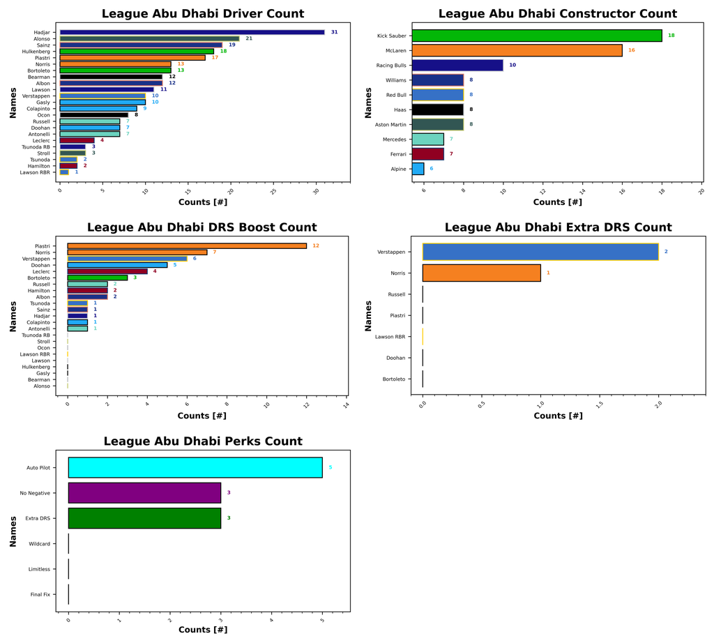

## Prizes

### Championship

| Prize Name | Prize Value | Terms | Manager | Team | Score |
| --- | --- | --- | --- | --- | --- |
|  | (%) |  |  |  |  |
| Champion of the World | 20 | Awarded to the top scorer in the league at the end of the season | Stefanus | Syahrul | 5091 |
| If You're Not First, You're Last | 10 | Awarded to the second place scorer in the league at the end of the season | Phil | BMW FTW | 4758 |
| Alpine Podium | 5 | Awarded to the third place scorer in the league at the end of the season | Patrick | You Hadjar Chance Racing | 4721 |
| Above Par | 20 | Awarded to the lowest scorer in the league at the end of the season, commonly referred to as the Golf League | Stuart | Taylormade To Lose | -268 |

### Achievements

| Prize Name | Prize Value | Terms | Managers | Teams | Scores | Details |
| --- | --- | --- | --- | --- | --- | --- |
|  | (%) |  |  |  |  |  |
| Cost Cappen | 5 | Highest average points per value at the end of the season | Phil Stefanus Patrick | BMW FTW Syahrul You Hadjar Chance Racing | 1.8592333436538047 1.8554760324681177 1.8478042263057946 |  |
| Sprint King | 5 | Highest score across the sprint races (China, Miami, Belgium, United States, Brazil, Qatar) | Stefanus Stefanus Josh | Haryanto Syahrul HSBC Jaguar Racing | 1590 1586 1476 |  |
| Flavio Controls Every Millimeter | 5 | Manager wide substitution count, highest wins | Stefanus Stefanus Sebastian | Gelael Haryanto BWT Racing Point F1 | 55 54 52 |  |
| The Triple Header | 5 | Highest score across the triple header races (Japan, Bahrain, Saudi Arabia, Emilia Romagna, Monaco, Spain, Las Vegas, Qatar, Abu Dhabi) | Stefanus Stefanus Val | Gelael Syahrul No U Turn | 2000 1912 1852 |  |
| I Forgot I Was Taking Part | 5 | Highest score in the first part of the season | Stefanus Stefanus Sebastian | Syahrul Haryanto Bridgestone Toro Rosso F1 | 3128 2924 2874 |  |
| Zak's Master Plan | 5 | Lowest score in the second half of the season | Stuart Valerie Valerie | Taylormade To Lose Stroll To The 18th Perez For World Champion | -266 -245 -211 |  |
| Mega Driver | 5 | Highest Extra DRS token score | Josh Madlen Stuart Sebastian Patrick | HSBC Jaguar Racing, Kingfisher Force India F1 Soft Tyres Are Red Andres Inyasista Allianz BMW Williams You Hadjar Chance Racing | 174 165 147 | Piastri Miami Norris Miami Norris Brazil |
| The Continental | 5 | Highest score across all 5 continents, Mexico classed as South America for inclusion only (Australia, Canada, Great Britain, Azerbaijan, Mexico) | Finn Stefanus Sebastian | Ro@d R@ge Syahrul Bridgestone Toro Rosso F1 | 767 760 758 |  |

### Spot Prizes

| Prize Name | Prize Value | Terms | Manager | Team | Score |
| --- | --- | --- | --- | --- | --- |
|  | (%) |  |  |  |  |
| The Ring | 1 | Highest score at the Austrian Grand Prix | Stefanus | Syahrul | 308 |
| Bottas Bowling | 1 | Highest score at the Hungarian Grand Prix | Stefanus | Haryanto | 301 |
| Daniel's Broken Hand | 1 | Lowest score at the Netherlands Grand Prix | Stuart | Taylormade To Lose | 22 |
| The Tifosi | 1 | Lowest score at the Italian Grand Prix | Valerie | Stroll To The 18th | -49 |
| Go For The Gap | 1 | Lowest score at the Singapore Grand Prix | Stuart | Taylormade To Lose | -41 |

## F1 Predict

Phil takes the final victory of the season with 104 points, a 50% accuracy. Josh is in second with 74 points, 27%, and Val in third with 41, 30%. Stuart, Pierce, and Matty all score 0 this week.

With that, the season comes to an end, and it is a commanding victory from Phil, with a total score of 1598 points and an accuracy of 45%. Josh finishes the season in second with 1205 points and a 36% accuracy. Val is in third with 1168 points and a 43% accuracy, and Stuart is in fourth place with 1126 points, a 45% accuracy. Pierce finishes in fifth place with 248 points and 45% accuracy, with Matty in last place with 95 points and 43% accuracy.

## Next Up

Prize giving. I will be dealing out the prize money in the near future, congratulations to all our winners. Keep your eyes out for the start of the 2026 season, with more to play for than ever before. Thank you all for a brilliant season, and thank you for taking part.